# Airbnb Listings in Texas Data Analysis

Author

Niharika Patil, Pratiksha Gadhe,Yashi Agarwal

#### What are the factors and features of a listing that make an Airbnb listing more expensive?

##### SUBQS: 1)How do ratings and reviews impact the pricing of Airbnb listings?

##### 2)Is the location or neighborhood a significant factor in determining the price of an Airbnb listing?

##### 3)Are specific property types, such as rental units, more expensive than others?

##### 4)Do the number of bedrooms and beds affect the price of an Airbnb listing?

##### 5)Are certain types of baths (private, shared, etc.) associated with higher or lower prices?

##### 6)Does the room type (e.g., private room, entire home) influence the pricing of Airbnb listings?

```r
library(tidyverse)
library(dplyr)
library(ggplot2)
airbnb <-read_csv("listings.csv")
head(airbnb)
```

```
# A tibble: 6 × 18
     id name        host_id host_name neighbourhood_group neighbourhood latitude
  <dbl> <chr>         <dbl> <chr>     <lgl>                       <dbl>    <dbl>
1  5456 Guesthouse…    8028 Sylvia    NA                          78702     30.3
2  5769 Home in Au…    8186 Elizabeth NA                          78729     30.5
3  6413 Guesthouse…   13879 Todd      NA                          78704     30.2
4  6448 Guesthouse…   14156 Amy       NA                          78704     30.3
5  8502 Guest suit…   25298 Karen     NA                          78741     30.2
6 13035 Home in Au…   50793 Molly     NA                          78702     30.3
# ℹ 11 more variables: longitude <dbl>, room_type <chr>, price <dbl>,
#   minimum_nights <dbl>, number_of_reviews <dbl>, last_review <date>,
#   reviews_per_month <dbl>, calculated_host_listings_count <dbl>,
#   availability_365 <dbl>, number_of_reviews_ltm <dbl>, license <lgl>
```

```r
str(airbnb)
```

```
spc_tbl_ [14,861 × 18] (S3: spec_tbl_df/tbl_df/tbl/data.frame)
 $ id                            : num [1:14861] 5456 5769 6413 6448 8502 ...
 $ name                          : chr [1:14861] "Guesthouse in Austin · ★4.84 · 1 bedroom · 2 beds · 1 bath" "Home in Austin · ★4.90 · 1 bedroom · 1 bed · 1 shared bath" "Guesthouse in Austin · ★4.97 · Studio · 1 bed · 1 bath" "Guesthouse in Austin · ★4.97 · 1 bedroom · 2 beds · 1 bath" ...
 $ host_id                       : num [1:14861] 8028 8186 13879 14156 25298 ...
 $ host_name                     : chr [1:14861] "Sylvia" "Elizabeth" "Todd" "Amy" ...
 $ neighbourhood_group           : logi [1:14861] NA NA NA NA NA NA ...
 $ neighbourhood                 : num [1:14861] 78702 78729 78704 78704 78741 ...
 $ latitude                      : num [1:14861] 30.3 30.5 30.2 30.3 30.2 ...
 $ longitude                     : num [1:14861] -97.7 -97.8 -97.7 -97.8 -97.7 ...
 $ room_type                     : chr [1:14861] "Entire home/apt" "Private room" "Entire home/apt" "Entire home/apt" ...
 $ price                         : num [1:14861] 126 45 57 159 48 123 107 65 250 180 ...
 $ minimum_nights                : num [1:14861] 2 1 30 3 4 30 3 30 1 7 ...
 $ number_of_reviews             : num [1:14861] 657 290 122 305 51 18 15 51 166 35 ...
 $ last_review                   : Date[1:14861], format: "2023-08-27" "2023-08-04" ...
 $ reviews_per_month             : num [1:14861] 3.72 1.77 0.73 2.09 0.31 0.12 1.4 0.31 1.01 0.21 ...
 $ calculated_host_listings_count: num [1:14861] 1 1 1 1 1 2 1 1 1 2 ...
 $ availability_365              : num [1:14861] 306 0 0 156 98 162 3 320 125 51 ...
 $ number_of_reviews_ltm         : num [1:14861] 42 21 3 17 3 2 15 3 2 0 ...
 $ license                       : logi [1:14861] NA NA NA NA NA NA ...
 - attr(*, "spec")=
  .. cols(
  ..   id = col_double(),
  ..   name = col_character(),
  ..   host_id = col_double(),
  ..   host_name = col_character(),
  ..   neighbourhood_group = col_logical(),
  ..   neighbourhood = col_double(),
  ..   latitude = col_double(),
  ..   longitude = col_double(),
  ..   room_type = col_character(),
  ..   price = col_double(),
  ..   minimum_nights = col_double(),
  ..   number_of_reviews = col_double(),
  ..   last_review = col_date(format = ""),
  ..   reviews_per_month = col_double(),
  ..   calculated_host_listings_count = col_double(),
  ..   availability_365 = col_double(),
  ..   number_of_reviews_ltm = col_double(),
  ..   license = col_logical()
  .. )
 - attr(*, "problems")=<externalptr>
```

```r
airbnb_2 <- subset(airbnb,select= -c(neighbourhood_group,license))
str(airbnb_2)
```

```
tibble [14,861 × 16] (S3: tbl_df/tbl/data.frame)
 $ id                            : num [1:14861] 5456 5769 6413 6448 8502 ...
 $ name                          : chr [1:14861] "Guesthouse in Austin · ★4.84 · 1 bedroom · 2 beds · 1 bath" "Home in Austin · ★4.90 · 1 bedroom · 1 bed · 1 shared bath" "Guesthouse in Austin · ★4.97 · Studio · 1 bed · 1 bath" "Guesthouse in Austin · ★4.97 · 1 bedroom · 2 beds · 1 bath" ...
 $ host_id                       : num [1:14861] 8028 8186 13879 14156 25298 ...
 $ host_name                     : chr [1:14861] "Sylvia" "Elizabeth" "Todd" "Amy" ...
 $ neighbourhood                 : num [1:14861] 78702 78729 78704 78704 78741 ...
 $ latitude                      : num [1:14861] 30.3 30.5 30.2 30.3 30.2 ...
 $ longitude                     : num [1:14861] -97.7 -97.8 -97.7 -97.8 -97.7 ...
 $ room_type                     : chr [1:14861] "Entire home/apt" "Private room" "Entire home/apt" "Entire home/apt" ...
 $ price                         : num [1:14861] 126 45 57 159 48 123 107 65 250 180 ...
 $ minimum_nights                : num [1:14861] 2 1 30 3 4 30 3 30 1 7 ...
 $ number_of_reviews             : num [1:14861] 657 290 122 305 51 18 15 51 166 35 ...
 $ last_review                   : Date[1:14861], format: "2023-08-27" "2023-08-04" ...
 $ reviews_per_month             : num [1:14861] 3.72 1.77 0.73 2.09 0.31 0.12 1.4 0.31 1.01 0.21 ...
 $ calculated_host_listings_count: num [1:14861] 1 1 1 1 1 2 1 1 1 2 ...
 $ availability_365              : num [1:14861] 306 0 0 156 98 162 3 320 125 51 ...
 $ number_of_reviews_ltm         : num [1:14861] 42 21 3 17 3 2 15 3 2 0 ...
```

### Data Cleaning

```r
# Define a function to insert ★ after the first period (.) in a string
# For data analysis, we need tidy data set. Each listing doesn't have ratings, so adding a dummy ratings value for analysis purpose.

add_star_if_needed <- function(x) {
  if (!grepl(" · ★", x)) {
    x <- sub(" · ", " · ★ 0 · ", x)
  }
  return(x)
}
```

```r
# Apply the function to the entire "name" column
airbnb_2$name <- lapply(airbnb_2$name, add_star_if_needed)
```

```r
airbnb_2 <- airbnb_2 |>
  separate(name, into = c("Type of House", "Ratings", "Bedroom", "Beds", "Baths"), sep = " · ")
airbnb_2
```

```
# A tibble: 14,861 × 20
      id `Type of House`       Ratings Bedroom    Beds   Baths host_id host_name
   <dbl> <chr>                 <chr>   <chr>      <chr>  <chr>   <dbl> <chr>
 1  5456 Guesthouse in Austin  ★4.84   1 bedroom  2 beds 1 ba…    8028 Sylvia
 2  5769 Home in Austin        ★4.90   1 bedroom  1 bed  1 sh…    8186 Elizabeth
 3  6413 Guesthouse in Austin  ★4.97   Studio     1 bed  1 ba…   13879 Todd
 4  6448 Guesthouse in Austin  ★4.97   1 bedroom  2 beds 1 ba…   14156 Amy
 5  8502 Guest suite in Austin ★4.56   1 bedroom  1 bed  1 ba…   25298 Karen
 6 13035 Home in Austin        ★5.0    2 bedrooms 2 beds 2 ba…   50793 Molly
 7 18258 Bungalow in Austin    ★5.0    3 bedrooms 2 beds 2 ba…   39458 Billy
 8 22828 Guesthouse in Austin  ★4.94   1 bedroom  1 bed  1 ba…   56488 David
 9 22982 Guesthouse in Austin  ★4.91   2 bedrooms 2 beds 1 ba…   89031 Gina
10 25028 Bungalow in Austin    ★4.94   2 bedrooms 2 beds 1 ba…  102862 Elana
# ℹ 14,851 more rows
# ℹ 12 more variables: neighbourhood <dbl>, latitude <dbl>, longitude <dbl>,
#   room_type <chr>, price <dbl>, minimum_nights <dbl>,
#   number_of_reviews <dbl>, last_review <date>, reviews_per_month <dbl>,
#   calculated_host_listings_count <dbl>, availability_365 <dbl>,
#   number_of_reviews_ltm <dbl>
```

```r
airbnb_2 <- airbnb_2 |>
  separate(`Type of House`, into = c("Type of House", "City"), sep = " in ")
airbnb_2
```

```
# A tibble: 14,861 × 21
      id `Type of House` City   Ratings Bedroom    Beds  Baths host_id host_name
   <dbl> <chr>           <chr>  <chr>   <chr>      <chr> <chr>   <dbl> <chr>
 1  5456 Guesthouse      Austin ★4.84   1 bedroom  2 be… 1 ba…    8028 Sylvia
 2  5769 Home            Austin ★4.90   1 bedroom  1 bed 1 sh…    8186 Elizabeth
 3  6413 Guesthouse      Austin ★4.97   Studio     1 bed 1 ba…   13879 Todd
 4  6448 Guesthouse      Austin ★4.97   1 bedroom  2 be… 1 ba…   14156 Amy
 5  8502 Guest suite     Austin ★4.56   1 bedroom  1 bed 1 ba…   25298 Karen
 6 13035 Home            Austin ★5.0    2 bedrooms 2 be… 2 ba…   50793 Molly
 7 18258 Bungalow        Austin ★5.0    3 bedrooms 2 be… 2 ba…   39458 Billy
 8 22828 Guesthouse      Austin ★4.94   1 bedroom  1 bed 1 ba…   56488 David
 9 22982 Guesthouse      Austin ★4.91   2 bedrooms 2 be… 1 ba…   89031 Gina
10 25028 Bungalow        Austin ★4.94   2 bedrooms 2 be… 1 ba…  102862 Elana
# ℹ 14,851 more rows
# ℹ 12 more variables: neighbourhood <dbl>, latitude <dbl>, longitude <dbl>,
#   room_type <chr>, price <dbl>, minimum_nights <dbl>,
#   number_of_reviews <dbl>, last_review <date>, reviews_per_month <dbl>,
#   calculated_host_listings_count <dbl>, availability_365 <dbl>,
#   number_of_reviews_ltm <dbl>
```

```r
# Remove the star character from 'Ratings'
airbnb_2$Ratings <- gsub("★", "", airbnb_2$Ratings)
airbnb_2
```

```
# A tibble: 14,861 × 21
      id `Type of House` City   Ratings Bedroom    Beds  Baths host_id host_name
   <dbl> <chr>           <chr>  <chr>   <chr>      <chr> <chr>   <dbl> <chr>
 1  5456 Guesthouse      Austin 4.84    1 bedroom  2 be… 1 ba…    8028 Sylvia
 2  5769 Home            Austin 4.90    1 bedroom  1 bed 1 sh…    8186 Elizabeth
 3  6413 Guesthouse      Austin 4.97    Studio     1 bed 1 ba…   13879 Todd
 4  6448 Guesthouse      Austin 4.97    1 bedroom  2 be… 1 ba…   14156 Amy
 5  8502 Guest suite     Austin 4.56    1 bedroom  1 bed 1 ba…   25298 Karen
 6 13035 Home            Austin 5.0     2 bedrooms 2 be… 2 ba…   50793 Molly
 7 18258 Bungalow        Austin 5.0     3 bedrooms 2 be… 2 ba…   39458 Billy
 8 22828 Guesthouse      Austin 4.94    1 bedroom  1 bed 1 ba…   56488 David
 9 22982 Guesthouse      Austin 4.91    2 bedrooms 2 be… 1 ba…   89031 Gina
10 25028 Bungalow        Austin 4.94    2 bedrooms 2 be… 1 ba…  102862 Elana
# ℹ 14,851 more rows
# ℹ 12 more variables: neighbourhood <dbl>, latitude <dbl>, longitude <dbl>,
#   room_type <chr>, price <dbl>, minimum_nights <dbl>,
#   number_of_reviews <dbl>, last_review <date>, reviews_per_month <dbl>,
#   calculated_host_listings_count <dbl>, availability_365 <dbl>,
#   number_of_reviews_ltm <dbl>
```

```r
#0 meant no ratings to the house, for analysis purpose rather than keeping it 0 which can be possible rating, gave the value 10.

#Ratings are out of 5. So any but (0 to 5 ) value seems reasonable.

# Replace " 0" with 10 in the Ratings column (no ratings)
airbnb_2$Ratings[airbnb_2$Ratings == " 0"] <- "10"


# Replace "New" with 11 in the Ratings column (new houses)
airbnb_2$Ratings[airbnb_2$Ratings == "New"] <- "11"


# Replace "studio" with 0 in airbnb_2$bedroom (no bedrooms/studio apts)
airbnb_2$Bedroom[airbnb_2$Bedroom == "Studio"] <- "0"

# Remove "bedroom" or "bedrooms" from the "Bedroom" column
airbnb_2$Bedroom <- gsub(c("bedroom", "bedrooms"), "", airbnb_2$Bedroom)
airbnb_2$Bedroom <- gsub("s", "", airbnb_2$Bedroom)

# Remove "bed" and "beds" from the "Beds" column
airbnb_2$Beds <- gsub(c("bed"), "", airbnb_2$Beds)
airbnb_2$Beds <- gsub(c("s"), "", airbnb_2$Beds)
```

```r
sum(is.na(airbnb_2$Baths))
```

```
[1] 168
```

```r
# Identify columns with NA values
cols_with_na <- colnames(airbnb_2)[colSums(is.na(airbnb_2)) > 0]
cols_with_na
```

```
[1] "Beds"              "Baths"             "host_name"
[4] "last_review"       "reviews_per_month"
```

```r
# Total NA cases
sum(is.na(airbnb_2$Beds))
```

```
[1] 6
```

```r
sum(is.na(airbnb_2$Baths))
```

```
[1] 168
```

```r
sum(is.na(airbnb_2$reviews_per_month))
```

```
[1] 3103
```

```r
# Drop rows with NA values in "beds" and "bathrooms" columns
airbnb_2 <- airbnb_2[complete.cases(airbnb_2[, c("Beds", "Baths")]), ]
```

```r
# Total NA cases
sum(is.na(airbnb_2$Beds))
```

```
[1] 0
```

```r
sum(is.na(airbnb_2$Baths))
```

```
[1] 0
```

```r
sum(is.na(airbnb_2$reviews_per_month))
```

```
[1] 3067
```

```r
# Check min and max values
summary(airbnb_2$reviews_per_month)
```

```
   Min. 1st Qu.  Median    Mean 3rd Qu.    Max.    NA's
   0.01    0.27    1.00    1.54    2.26   26.25    3067
```

```r
str(airbnb_2$reviews_per_month)
```

```
 num [1:14693] 3.72 1.77 0.73 2.09 0.31 0.12 1.4 0.31 1.01 0.21 ...
```

```r
# Replace NA which means no reviews with 100
airbnb_2$reviews_per_month[is.na(airbnb_2$reviews_per_month)] <- 100
```

```r
str(airbnb_2)
```

```
tibble [14,693 × 21] (S3: tbl_df/tbl/data.frame)
 $ id                            : num [1:14693] 5456 5769 6413 6448 8502 ...
 $ Type of House                 : chr [1:14693] "Guesthouse" "Home" "Guesthouse" "Guesthouse" ...
 $ City                          : chr [1:14693] "Austin" "Austin" "Austin" "Austin" ...
 $ Ratings                       : chr [1:14693] "4.84" "4.90" "4.97" "4.97" ...
 $ Bedroom                       : chr [1:14693] "1 " "1 " "0" "1 " ...
 $ Beds                          : chr [1:14693] "2 " "1 " "1 " "2 " ...
 $ Baths                         : chr [1:14693] "1 bath" "1 shared bath" "1 bath" "1 bath" ...
 $ host_id                       : num [1:14693] 8028 8186 13879 14156 25298 ...
 $ host_name                     : chr [1:14693] "Sylvia" "Elizabeth" "Todd" "Amy" ...
 $ neighbourhood                 : num [1:14693] 78702 78729 78704 78704 78741 ...
 $ latitude                      : num [1:14693] 30.3 30.5 30.2 30.3 30.2 ...
 $ longitude                     : num [1:14693] -97.7 -97.8 -97.7 -97.8 -97.7 ...
 $ room_type                     : chr [1:14693] "Entire home/apt" "Private room" "Entire home/apt" "Entire home/apt" ...
 $ price                         : num [1:14693] 126 45 57 159 48 123 107 65 250 180 ...
 $ minimum_nights                : num [1:14693] 2 1 30 3 4 30 3 30 1 7 ...
 $ number_of_reviews             : num [1:14693] 657 290 122 305 51 18 15 51 166 35 ...
 $ last_review                   : Date[1:14693], format: "2023-08-27" "2023-08-04" ...
 $ reviews_per_month             : num [1:14693] 3.72 1.77 0.73 2.09 0.31 0.12 1.4 0.31 1.01 0.21 ...
 $ calculated_host_listings_count: num [1:14693] 1 1 1 1 1 2 1 1 1 2 ...
 $ availability_365              : num [1:14693] 306 0 0 156 98 162 3 320 125 51 ...
 $ number_of_reviews_ltm         : num [1:14693] 42 21 3 17 3 2 15 3 2 0 ...
```

```r
columns_to_convert_factor <- c("Type of House", "City", "Baths", "room_type")

columns_to_convert_num <- c("Ratings", "Bedroom", "Beds")

# Convert the specified columns to factors using lapply
airbnb_2[columns_to_convert_factor] <- lapply(airbnb_2[columns_to_convert_factor], factor)


# Convert the specified columns to num using lapply
airbnb_2[columns_to_convert_num] <- lapply(airbnb_2[columns_to_convert_num], as.numeric)
```

```r
levels(airbnb_2$City)
```

```
 [1] "austin"                 "Austin"                 "Austin "
 [4] "Austin Texas"           "Bee Cave"               "Briarcliff"
 [7] "Buda"                   "Clarksville"            "Del Valle"
[10] "Dripping Springs"       "East Austin"            "Hays County"
[13] "Lake Travis"            "Lakeway"                "Manchaca"
[16] "Manor"                  "Pflugerville"           "Rollingwood"
[19] "Round Rock"             "Smith County"           "Spicewood"
[22] "Sunset Valley"          "Texas"                  "The Hills"
[25] "Travis County"          "West Lake Hills"        "Westlake Hills"
[28] "Westlake Hills, Austin"
```

```r
airbnb_2$City <- as.character(airbnb_2$City)
airbnb_2$City <- gsub("austin", "Austin", airbnb_2$City)
airbnb_2$City <- gsub("Austin ", "Austin", airbnb_2$City)
airbnb_2$City <- gsub("Austin Texas", "Austin", airbnb_2$City)
airbnb_2$City <- gsub("East Austin", "Austin", airbnb_2$City)
```

```r
airbnb_2$City <- as.factor(airbnb_2$City)
levels(airbnb_2$City )
```

```
 [1] "Austin"                 "AustinTexas"            "Bee Cave"
 [4] "Briarcliff"             "Buda"                   "Clarksville"
 [7] "Del Valle"              "Dripping Springs"       "Hays County"
[10] "Lake Travis"            "Lakeway"                "Manchaca"
[13] "Manor"                  "Pflugerville"           "Rollingwood"
[16] "Round Rock"             "Smith County"           "Spicewood"
[19] "Sunset Valley"          "Texas"                  "The Hills"
[22] "Travis County"          "West Lake Hills"        "Westlake Hills"
[25] "Westlake Hills, Austin"
```

```r
airbnb_2$City <- as.character(airbnb_2$City)
airbnb_2$City <- gsub("AustinTexas", "Austin", airbnb_2$City)
airbnb_2$City <- gsub("West Lake Hills", "Westlake Hills", airbnb_2$City)
airbnb_2$City <- gsub("Westlake Hills, Austin", "Westlake Hills", airbnb_2$City)
airbnb_2$City <- gsub("Texas", "Westlake Hills", airbnb_2$City)
```

```r
airbnb_2$City <- as.factor(airbnb_2$City)
levels(airbnb_2$City )
```

```
 [1] "Austin"           "Bee Cave"         "Briarcliff"       "Buda"
 [5] "Clarksville"      "Del Valle"        "Dripping Springs" "Hays County"
 [9] "Lake Travis"      "Lakeway"          "Manchaca"         "Manor"
[13] "Pflugerville"     "Rollingwood"      "Round Rock"       "Smith County"
[17] "Spicewood"        "Sunset Valley"    "The Hills"        "Travis County"
[21] "Westlake Hills"
```

```r
table(airbnb_2$City)
```

```
          Austin         Bee Cave       Briarcliff             Buda
           14489               24                1                2
     Clarksville        Del Valle Dripping Springs      Hays County
               1                3                4                1
     Lake Travis          Lakeway         Manchaca            Manor
               1               87                4                1
    Pflugerville      Rollingwood       Round Rock     Smith County
               5                2                3                1
       Spicewood    Sunset Valley        The Hills    Travis County
               1               13               10                2
  Westlake Hills
              38
```

```r
table(airbnb_2$`Type of House`)
```

```
        Aparthotel               Barn  Bed and breakfast               Boat
                 5                  2                 12                  6
    Boutique hotel           Bungalow                Bus              Cabin
                30                259                  7                 56
         Camper/RV           Campsite    casa particular             Chalet
               111                  4                  3                  1
             Condo            Cottage               Dome       Earthen home
              1347                 76                  2                  2
         Farm stay        Guest suite         Guesthouse               Home
                 4                314                687               7205
            Hostel              Hotel          Houseboat               Loft
                 4                128                  2                109
     Place to stay              Ranch        Rental unit             Resort
                36                  2               3442                 79
Serviced apartment Shipping container               Tent          Tiny home
               107                  5                  3                110
              Tipi              Tower          Townhouse          Treehouse
                 1                  4                413                  6
     Vacation home              Villa               Yurt
                26                 79                  4
```

```r
table(airbnb_2$Baths)
```

```
          0 baths    0 shared baths            1 bath    1 private bath
              115                32              6115               798
    1 shared bath         1.5 baths  1.5 shared baths          10 baths
              774               651               169                 1
       10.5 baths        11.5 baths          12 baths        12.5 baths
                1                 1                 1                 1
         17 baths           2 baths    2 shared baths         2.5 baths
                1              3230                43              1215
 2.5 shared baths           3 baths    3 shared baths         3.5 baths
               13               730                10               293
 3.5 shared baths           4 baths    4 shared baths         4.5 baths
                1               230                 2                87
          5 baths         5.5 baths           6 baths         6.5 baths
               62                42                22                14
          7 baths         7.5 baths           8 baths         8.5 baths
               11                 4                 7                 1
        9.5 baths         Half-bath Private half-bath  Shared half-bath
                1                 7                 3                 5
```

```r
table(airbnb_2$room_type)
```

```
Entire home/apt      Hotel room    Private room     Shared room
          12089               3            2483             118
```

```r
# Convert the character dates to Date objects
airbnb_2$last_review <- as.Date(airbnb_2$last_review, format = "%Y-%m-%d")
```

```r
str(airbnb_2)
```

```
tibble [14,693 × 21] (S3: tbl_df/tbl/data.frame)
 $ id                            : num [1:14693] 5456 5769 6413 6448 8502 ...
 $ Type of House                 : Factor w/ 39 levels "Aparthotel","Barn",..: 19 20 19 19 18 20 6 19 19 6 ...
 $ City                          : Factor w/ 21 levels "Austin","Bee Cave",..: 1 1 1 1 1 1 1 1 1 1 ...
 $ Ratings                       : num [1:14693] 4.84 4.9 4.97 4.97 4.56 5 5 4.94 4.91 4.94 ...
 $ Bedroom                       : num [1:14693] 1 1 0 1 1 2 3 1 2 2 ...
 $ Beds                          : num [1:14693] 2 1 1 2 1 2 2 1 2 2 ...
 $ Baths                         : Factor w/ 36 levels "0 baths","0 shared baths",..: 3 5 3 3 3 14 14 3 3 3 ...
 $ host_id                       : num [1:14693] 8028 8186 13879 14156 25298 ...
 $ host_name                     : chr [1:14693] "Sylvia" "Elizabeth" "Todd" "Amy" ...
 $ neighbourhood                 : num [1:14693] 78702 78729 78704 78704 78741 ...
 $ latitude                      : num [1:14693] 30.3 30.5 30.2 30.3 30.2 ...
 $ longitude                     : num [1:14693] -97.7 -97.8 -97.7 -97.8 -97.7 ...
 $ room_type                     : Factor w/ 4 levels "Entire home/apt",..: 1 3 1 1 1 1 1 1 1 1 ...
 $ price                         : num [1:14693] 126 45 57 159 48 123 107 65 250 180 ...
 $ minimum_nights                : num [1:14693] 2 1 30 3 4 30 3 30 1 7 ...
 $ number_of_reviews             : num [1:14693] 657 290 122 305 51 18 15 51 166 35 ...
 $ last_review                   : Date[1:14693], format: "2023-08-27" "2023-08-04" ...
 $ reviews_per_month             : num [1:14693] 3.72 1.77 0.73 2.09 0.31 0.12 1.4 0.31 1.01 0.21 ...
 $ calculated_host_listings_count: num [1:14693] 1 1 1 1 1 2 1 1 1 2 ...
 $ availability_365              : num [1:14693] 306 0 0 156 98 162 3 320 125 51 ...
 $ number_of_reviews_ltm         : num [1:14693] 42 21 3 17 3 2 15 3 2 0 ...
```

```r
airbnb_2
```

```
# A tibble: 14,693 × 21
      id `Type of House` City   Ratings Bedroom  Beds Baths    host_id host_name
   <dbl> <fct>           <fct>    <dbl>   <dbl> <dbl> <fct>      <dbl> <chr>
 1  5456 Guesthouse      Austin    4.84       1     2 1 bath      8028 Sylvia
 2  5769 Home            Austin    4.9        1     1 1 share…    8186 Elizabeth
 3  6413 Guesthouse      Austin    4.97       0     1 1 bath     13879 Todd
 4  6448 Guesthouse      Austin    4.97       1     2 1 bath     14156 Amy
 5  8502 Guest suite     Austin    4.56       1     1 1 bath     25298 Karen
 6 13035 Home            Austin    5          2     2 2 baths    50793 Molly
 7 18258 Bungalow        Austin    5          3     2 2 baths    39458 Billy
 8 22828 Guesthouse      Austin    4.94       1     1 1 bath     56488 David
 9 22982 Guesthouse      Austin    4.91       2     2 1 bath     89031 Gina
10 25028 Bungalow        Austin    4.94       2     2 1 bath    102862 Elana
# ℹ 14,683 more rows
# ℹ 12 more variables: neighbourhood <dbl>, latitude <dbl>, longitude <dbl>,
#   room_type <fct>, price <dbl>, minimum_nights <dbl>,
#   number_of_reviews <dbl>, last_review <date>, reviews_per_month <dbl>,
#   calculated_host_listings_count <dbl>, availability_365 <dbl>,
#   number_of_reviews_ltm <dbl>
```

- There are 39 types of houses.
- There are 21 Locations in Texas.
- There are 36 types of Baths.
- There are 4 room types.

### Exploratory data analysis, data visualization, and statistical analysis.

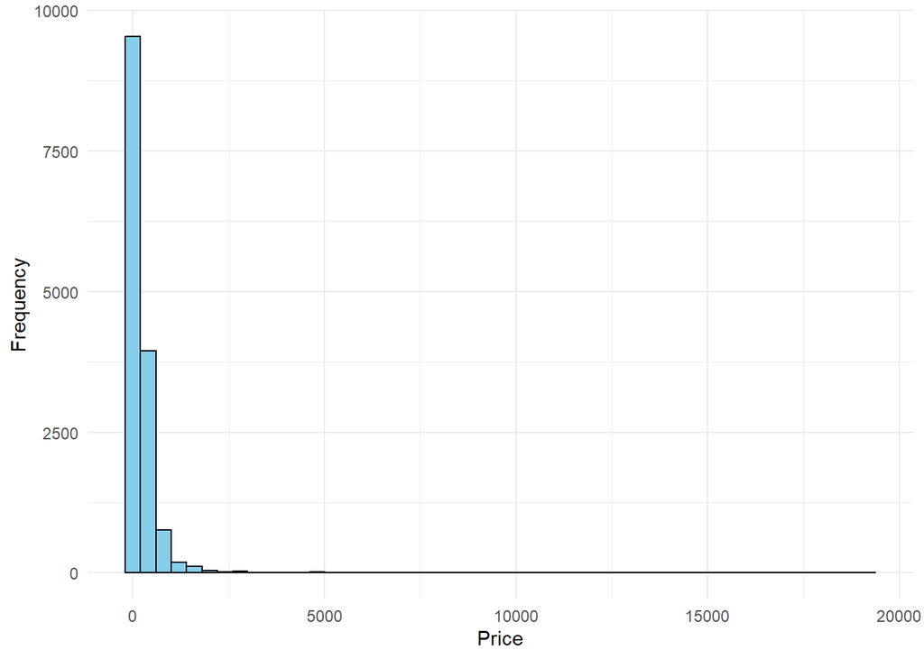

```r
#Univariate Analysis: Examining each variable individually.
# Checking for Outliers in price

#install.packages("gridExtra")
library(gridExtra)
  ggplot(data = airbnb_2, aes(x = price)) +
  geom_histogram(binwidth = 400, fill = "skyblue", color = "black") +
  labs(x = "Price", y = "Frequency") +
  theme_minimal()
```

- This plot shows there are some extreme outliers present in price making it rightly skewed. This can be luxurious home, or price might be a human error. It makes it different from rest of the cluster. Therefore, not considering outliers for this analysis.

```r
# Removing the Outliers in the price
# Calculate the IQR for the 'price' variable

Q1 <- quantile(airbnb_2$price, 0.25)
Q3 <- quantile(airbnb_2$price, 0.75)
IQR <- Q3 - Q1

# Define the lower and upper bounds for identifying outliers
lower_bound <- Q1 - 1.5 * IQR
upper_bound <- Q3 + 1.5 * IQR

# Identify outliers
outliers <- airbnb_2$price < lower_bound | airbnb_2$price > upper_bound

# Create a new dataset without outliers
airbnb_no_outliers <- airbnb_2[!outliers, ]

# Check the dimensions of the new dataset
dim(airbnb_no_outliers)
```

```
[1] 13246    21
```

```r
# Summary Statistics:
summary(airbnb_no_outliers)
```

```
       id                Type of House              City          Ratings
 Min.   :5.456e+03   Home       :6177   Austin        :13080   Min.   : 0.000
 1st Qu.:2.469e+07   Rental unit:3318   Lakeway       :   77   1st Qu.: 4.850
 Median :5.216e+07   Condo      :1298   Westlake Hills:   24   Median : 5.000
 Mean   :3.495e+17   Guesthouse : 679   Bee Cave      :   22   Mean   : 6.604
 3rd Qu.:7.616e+17   Townhouse  : 382   The Hills     :    8   3rd Qu.:10.000
 Max.   :9.771e+17   Guest suite: 312   Sunset Valley :    6   Max.   :11.000
                     (Other)    :1080   (Other)       :   29
    Bedroom          Beds                   Baths         host_id
 Min.   : 0.0   Min.   : 1.000   1 bath        :5966   Min.   :       23
 1st Qu.: 1.0   1st Qu.: 1.000   2 baths       :2950   1st Qu.: 16870974
 Median : 2.0   Median : 2.000   2.5 baths     :1031   Median : 69989580
 Mean   : 1.8   Mean   : 2.354   1 private bath: 776   Mean   :146392822
 3rd Qu.: 2.0   3rd Qu.: 3.000   1 shared bath : 770   3rd Qu.:259827584
 Max.   :13.0   Max.   :25.000   1.5 baths     : 633   Max.   :536308631
                                 (Other)       :1120
  host_name         neighbourhood      latitude       longitude
 Length:13246       Min.   :78701   Min.   :30.08   Min.   :-98.05
 Class :character   1st Qu.:78704   1st Qu.:30.24   1st Qu.:-97.77
 Mode  :character   Median :78723   Median :30.27   Median :-97.74
                    Mean   :78725   Mean   :30.28   Mean   :-97.75
                    3rd Qu.:78745   3rd Qu.:30.31   3rd Qu.:-97.72
                    Max.   :78759   Max.   :30.52   Max.   :-97.56

           room_type         price       minimum_nights     number_of_reviews
 Entire home/apt:10743   Min.   :  1.0   Min.   :   1.000   Min.   :   0.00
 Hotel room     :    2   1st Qu.: 90.0   1st Qu.:   1.000   1st Qu.:   1.00
 Private room   : 2384   Median :137.0   Median :   2.000   Median :   9.00
 Shared room    :  117   Mean   :169.3   Mean   :   7.851   Mean   :  39.72
                         3rd Qu.:221.0   3rd Qu.:   3.000   3rd Qu.:  40.00
                         Max.   :527.0   Max.   :1124.000   Max.   :1141.00

  last_review         reviews_per_month calculated_host_listings_count
 Min.   :2012-03-15   Min.   :  0.01    Min.   :  1.00
 1st Qu.:2022-11-10   1st Qu.:  0.41    1st Qu.:  1.00
 Median :2023-07-19   Median :  1.59    Median :  2.00
 Mean   :2022-08-27   Mean   : 20.67    Mean   : 11.12
 3rd Qu.:2023-08-25   3rd Qu.:  4.51    3rd Qu.:  6.00
 Max.   :2023-09-10   Max.   :100.00    Max.   :136.00
 NA's   :2567
 availability_365 number_of_reviews_ltm
 Min.   :  0.0    Min.   :  0.00
 1st Qu.:  2.0    1st Qu.:  0.00
 Median :123.0    Median :  3.00
 Mean   :149.9    Mean   : 11.01
 3rd Qu.:295.0    3rd Qu.: 16.00
 Max.   :365.0    Max.   :258.00
```

```r
# Number of Airbnb properties under each host_id's.

filtered <- airbnb_no_outliers%>%
  group_by(`host_id`) %>%
  summarize(count = n()) %>%
  arrange(desc(count))
filtered
```

```
# A tibble: 8,008 × 2
     host_id count
       <dbl> <int>
 1 107434423   136
 2 274552333   126
 3 263502162   112
 4   8167447    88
 5 464404919    84
 6  35817561    77
 7 501999514    56
 8 276920863    49
 9 414484382    47
10 475533011    47
# ℹ 7,998 more rows
```

- 107434423 host_id has most of the houses listed on Airbnb.

```r
# Ratings given to Airbnb based on days of the week.

# Using the mutate function to add the day of the week column to dataset
airbnb_no_outliers <- airbnb_no_outliers %>%
  mutate(day_of_week = weekdays(airbnb_no_outliers$last_review))

# ratings count by day of the week
result <- airbnb_no_outliers %>%
  group_by(day_of_week) %>%
  summarise(count = n()) %>%
  arrange(desc(count))

result
```

```
# A tibble: 8 × 2
  day_of_week count
  <chr>       <int>
1 Sunday       3528
2 <NA>         2567
3 Monday       2485
4 Saturday     1323
5 Friday        998
6 Tuesday       869
7 Wednesday     764
8 Thursday      712
```

```r
# Top rated Hosts
ratings_value <- subset(airbnb_no_outliers,select= c(host_name, Ratings, City,`Type of House`,number_of_reviews_ltm ))

ratings_values_true <- ratings_value %>%
  filter(Ratings >= 0 & Ratings <= 5 & !(Ratings %in% c(10, 11))) %>%
  arrange(desc(Ratings))
ratings_values_true
```

```
# A tibble: 8,868 × 5
   host_name Ratings City   `Type of House` number_of_reviews_ltm
   <chr>       <dbl> <fct>  <fct>                           <dbl>
 1 Molly           5 Austin Home                                2
 2 Billy           5 Austin Bungalow                           15
 3 Belinda         5 Austin Home                                2
 4 Rachel          5 Austin Home                                3
 5 Tracy           5 Austin Loft                                1
 6 Eric            5 Austin Home                                1
 7 Janet           5 Austin Home                                0
 8 Julie           5 Austin Home                                8
 9 Teresa          5 Austin Home                                0
10 Mike            5 Austin Home                                0
# ℹ 8,858 more rows
```

```r
# filtering out hosts with ratings 5/5
count_of_hosts_with_rating_5 <- ratings_values_true %>%
  filter(Ratings == 5) %>%
  summarise(count = n())

count_of_hosts_with_rating_5
```

```
# A tibble: 1 × 1
  count
  <int>
1  2292
```

- Top 10 hosts are based in Austin area with ratings 5/5.
- There are 2292 hosts with 5/5 ratings.

```r
# Most popular type of house
popular_types <- ratings_values_true %>%
                       group_by(`Type of House`) %>%
                             summarise(count = n()) %>%
                                  arrange(desc(count))
popular_types
```

```
# A tibble: 38 × 2
   `Type of House` count
   <fct>           <int>
 1 Home             4228
 2 Rental unit      1791
 3 Condo             918
 4 Guesthouse        613
 5 Townhouse         291
 6 Guest suite       289
 7 Bungalow          227
 8 Tiny home          91
 9 Camper/RV          81
10 Loft               81
# ℹ 28 more rows
```

- ” Home” is most popular AirBnB type of house in the Texas. Followed by Rental units and Condos.

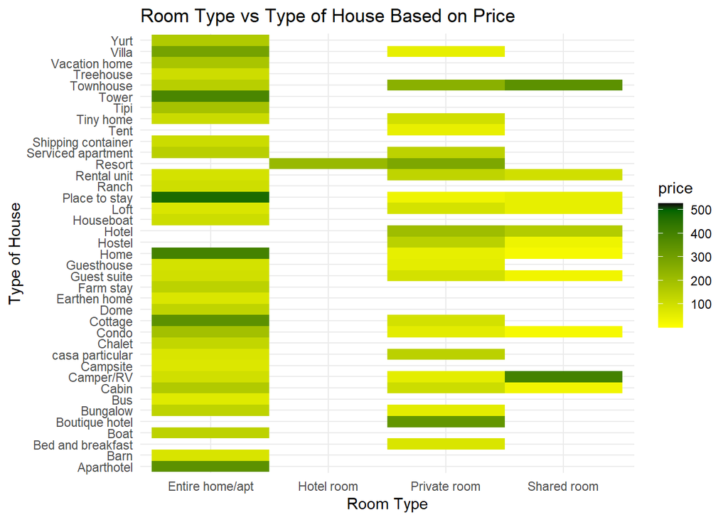

```r
# Price based on Room Type vs Type of House

ggplot(airbnb_no_outliers, aes(x = room_type, y = `Type of House`, fill = price)) +
  geom_tile() +
  labs(title = "Room Type vs Type of House Based on Price") +
  xlab("Room Type") +
  ylab("Type of House") +
  scale_fill_gradientn(colors = c("yellow", "darkgreen", "black"), values = scales::rescale(c(0, 500, max(airbnb_no_outliers$price)))) +
  theme_minimal()
```

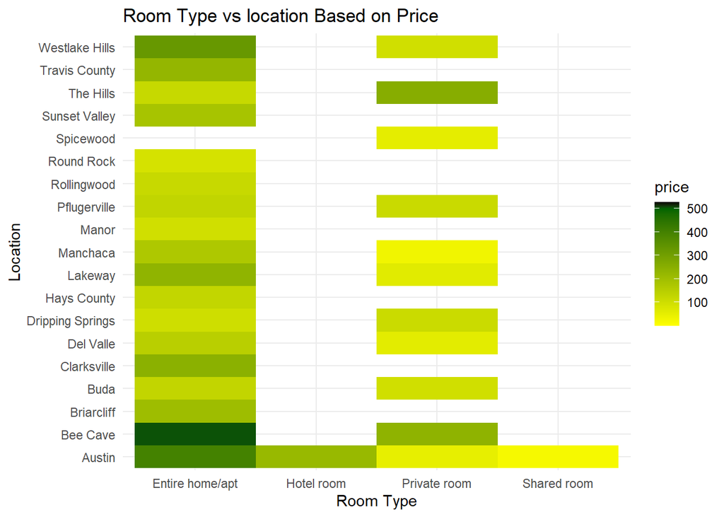

```r
# Price based on Room Type vs Location

ggplot(airbnb_no_outliers, aes(x = room_type, y = City, fill = price)) +
  geom_tile() +
  labs(title = "Room Type vs location Based on Price") +
  xlab("Room Type") +
  ylab("Location") +
  scale_fill_gradientn(colors = c("yellow", "darkgreen", "black"), values = scales::rescale(c(0, 500, max(airbnb_no_outliers$price)))) +
  theme_minimal()
```

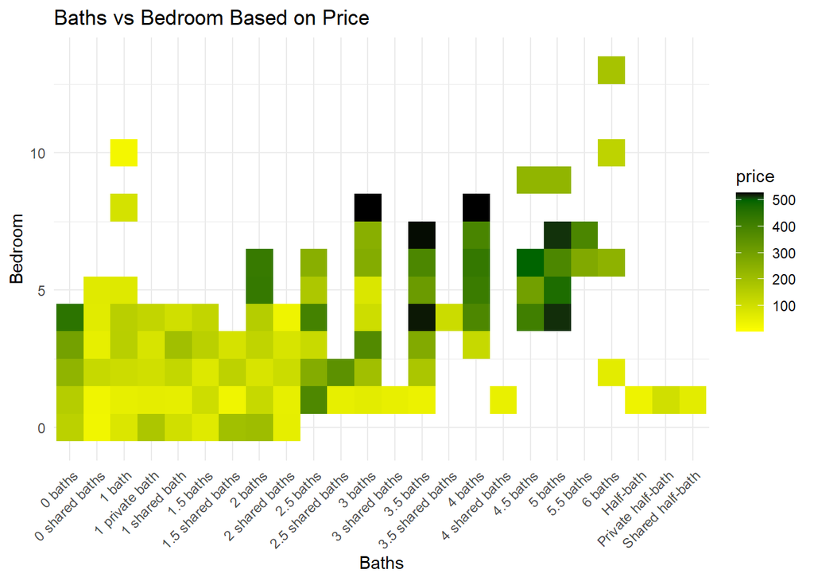

```r
# Price based on Baths vs Bedrooms

ggplot(airbnb_no_outliers, aes(x = Baths, y = Bedroom, fill = price)) +
  geom_tile() +
  labs(title = "Baths vs Bedroom Based on Price") +
  xlab("Baths") +
  ylab("Bedroom") +
  scale_fill_gradientn(colors = c("yellow", "darkgreen", "black"), values = scales::rescale(c(0, 500, max(airbnb_no_outliers$price)))) +
  theme_minimal() +
  theme(axis.text.x = element_text(angle = 45, hjust = 1))
```

- The price is higher for bathrooms in range of 3 to 5.5 and bedrooms in range 4 to 8.
- Rest of types of bedrooms and baths have lesser price.

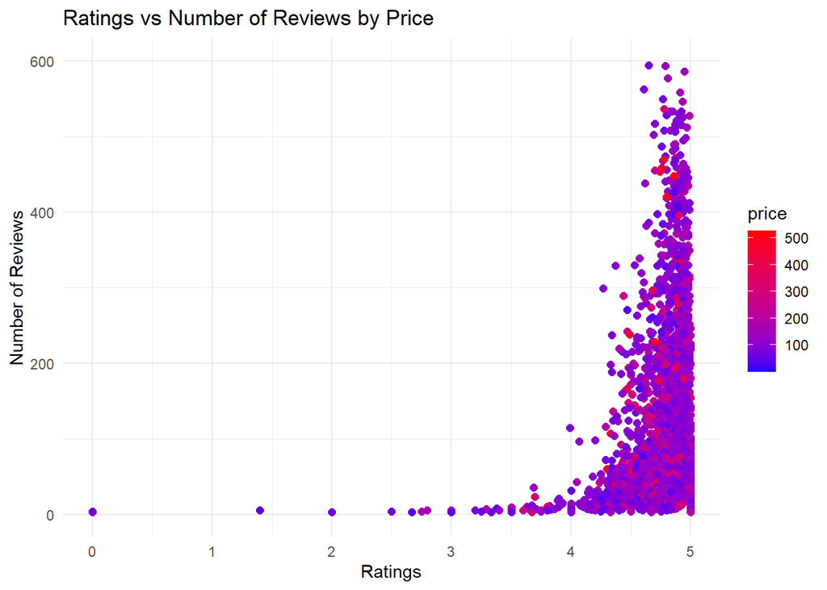

```r
# Price based on Ratings vs Number of Reviews

ggplot(airbnb_no_outliers, aes(x = Ratings, y = number_of_reviews, color = price)) +
  geom_point(size = 2) +
  labs(title = "Ratings vs Number of Reviews by Price") +
  xlab("Ratings") +
  ylab("Number of Reviews") +
  theme_minimal() +
  scale_color_gradient(low = "blue", high = "red") +
  xlim(0, 5) +
  ylim(0, 600)
```

- The scatter plot appears to show a scattered distribution of data points, which suggests that there isn’t a strong, linear correlation between ratings, number of reviews and price. Listings with different ratings and number of reviews can be found at various price points.
- Outliers: There might be some outliers, which are listings with high prices but varying ratings, number of ratings. These outliers could indicate unique, premium listings.
- Clusters: While there isn’t a clear linear trend, we might notice some loose clusters or patterns. For example,many highly-rated listings are concentrated in a specific price range, or that low-rated listings are often more budget-friendly. However, these clusters are not as pronounced.

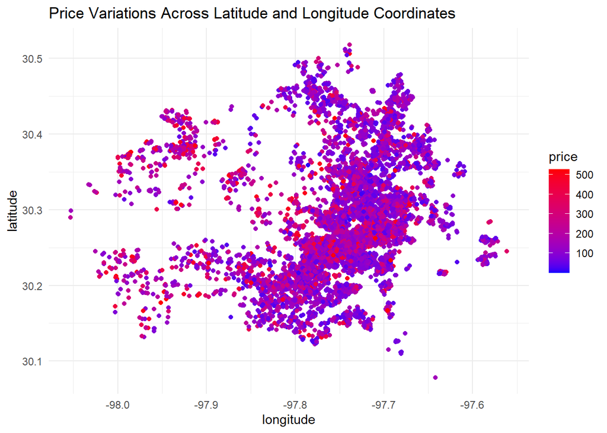

```r
# Price based on longitude vs latitude

ggplot(airbnb_no_outliers, aes(x = longitude, y = latitude, color = price)) +
  geom_point() +
  labs(title = "Price Variations Across Latitude and Longitude Coordinates") +
  scale_color_gradient(low = "blue", high = "red") +
  theme_minimal()
```

- From the above plot we can see that there is no strong correlation of latitude, Longitude with prices. Although we can see that at longitude greater than -97.8 there are some lesser price airbnbs along with some higher price ones.

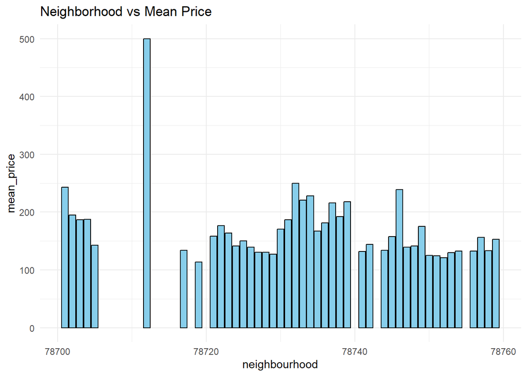

```r
# Neighborhood vs Mean Price
airbnb_no_outliers_summary <- airbnb_no_outliers %>%
  group_by(neighbourhood) %>%
  summarize(mean_price = mean(price),number_of_listings = n())

ggplot(airbnb_no_outliers_summary, aes(x = neighbourhood, y = mean_price)) +
  geom_bar(stat = "identity", fill = "skyblue", color = "black") +
  labs(title = "Neighborhood vs Mean Price") +
  theme(axis.text.x = element_text(angle = 45, hjust = 1)) +
  theme_minimal()
```

```r
# Sort the summary data by mean price in descending order
sorted_summary <- airbnb_no_outliers_summary[order(airbnb_no_outliers_summary$mean_price, decreasing = TRUE), ]

# Extract the neighborhood with the highest mean price
highest_mean_price_neighborhood <- sorted_summary$neighbourhood[1]
highest_mean_price <- sorted_summary$mean_price[1]

# Extract the neighborhood with the lowest mean price
lowest_mean_price_neighborhood <- sorted_summary$neighbourhood[nrow(sorted_summary)]
lowest_mean_price <- sorted_summary$mean_price[nrow(sorted_summary)]

cat("Neighborhood with the highest mean price:", highest_mean_price_neighborhood, "($", highest_mean_price, ")\n")
```

```
Neighborhood with the highest mean price: 78712 ($ 500 )
```

```r
cat("Neighborhood with the lowest mean price:", lowest_mean_price_neighborhood, "($", lowest_mean_price, ")\n")
```

```
Neighborhood with the lowest mean price: 78719 ($ 113.8421 )
```

- On x-axis, each bar corresponds to a different neighbourhood.
- On y-axis, the mean_price indicates average price range for Airbnb listings that visitors can expect to encounter when booking accommodations in that neighbourhood.
- By analyzing the number of listings and prices for each neighborhood, we can observe the price variation across different neighbourhoods.Some neighbourhoods have expensive listings while others are more affordable.
- Neighborhood with the highest mean price: 78712 ($ 500 )
- Neighborhood with the lowest mean price: 78719 ($ 113.8421 )